# New York City Council: local ideal points, 2014–2026

Pooled stated-meeting roll calls · Preliminary analysis

Author

Boris Shor

Updated

October 8, 2026

This analysis places every member of the New York City Council who cast a recorded vote between November 2014 and September 2026 on one voting scale — 123 people across five council classes. The current and historical plots use the same pooled coordinates.

The recovered dimension closely tracks independently researched party affiliation, caucus membership, and DSA endorsements. It is also associated with how districts voted for president, council, and mayor. The current council’s party groups separate completely; the historical sample has a small, informative overlap.

**123 members**  
Across five council classes

**51 districts**  
One pooled voting scale

**1,239 roll calls**  
Contested council decisions

**58,468 votes**  
Recorded yeas and nays

## Dataset

The roll calls come from the *MyTown* corpus of local-government meetings and votes (Jacob Greene, 2026, CC BY 4.0, [DOI 10.57967/hf/9676](https://doi.org/10.57967/hf/9676)), release of September 18, 2026. Preserved local extracts, rather than later downloads, define this analysis.

### Coverage and construction

| Measure | Value |
| --- | --- |
| Member-vote records | 293,979 |
| Stated meetings | 207 |
| Coverage | November 13, 2014 – September 10, 2026 |
| People | 123 |
| Meeting–motion items | 5,842 |
| One-member-minority items | 502 |
| Items retained for the fit | 1,239 |
| Usable yea/nay votes | 58,468 |
| Members of the council seated January 2026 | 52 |

Each recorded meeting–motion combination is treated as a voting item. Yea is coded 1 and nay 0. Every other recorded status — absence, abstention, medical, maternity, paternity, bereavement, suspension — is missing, never a nay. We retain votes with at least one member on each side and at least 40 recorded yeas or nays, leaving **1,239 contested roll calls**. This includes 502 single-dissenter items. Unanimous business is excluded.

Fifty-two people appear in the current council because Erik Bottcher voted at the January 15, 2026 meeting before leaving the seat now held by another member.

## Results

### The council seated in January 2026

An **ideal point** is a one-dimensional summary of voting similarity: members near one another take the same side on contested roll calls, and members far apart oppose one another. The units are specific to this New York sample and cannot be compared numerically with the Chicago, Denver, or Houston scores.

[figure not shown]

Members of the council seated in January 2026, ordered by ideal point. Color shows party affiliation researched independently of roll calls; bars are 95% posterior intervals.

The current council runs from **Tiffany Cabán** (-1.07) and **Alexa Avilés** (-1.06) at one end to **Vickie Paladino** (2.02), **Inna Vernikov** (1.96), **David Carr** (1.96) and **Joann Ariola** (1.90) at the other. Most Democrats sit in a crowded middle whose intervals overlap heavily; the ordering within that middle should not be read as a ranking.

Across the full twelve years, **Charles Barron** (-6.72) is the negative endpoint, while **Steven Matteo** (2.88) and **Joseph Borelli** (2.60) occupy the positive end. **Jumaane Williams** sits at -1.10. **Vincent Ignizio** (2.79) rests on only 5 retained votes.

### The Barrons

Charles and Inez Barron both appear near the progressive end, but Charles is an especially pronounced outlier. His estimate is -6.72, with a 95% interval from -8.48 to -5.25; Inez’s is -1.75. Charles cast the sole nay on **131 of 336 retained votes (39%)**, and Inez on **135 of 596 (23%)**. These isolated dissents distinguish both members from their colleagues.

These are voting positions, not literal distances in political belief. Charles’s exceptionally isolated record produces an extreme, imprecisely estimated coordinate. He remains in the council plots but is excluded from the state-space bridge regression below; Inez remains a bridge. The two are separate officeholders with different vote histories, not interchangeable records.

### The earlier councils

Each council below is drawn on the same axis, so positions can be compared across classes. Coordinates come from the single pooled fit rather than from separate models.

**2024–2025**

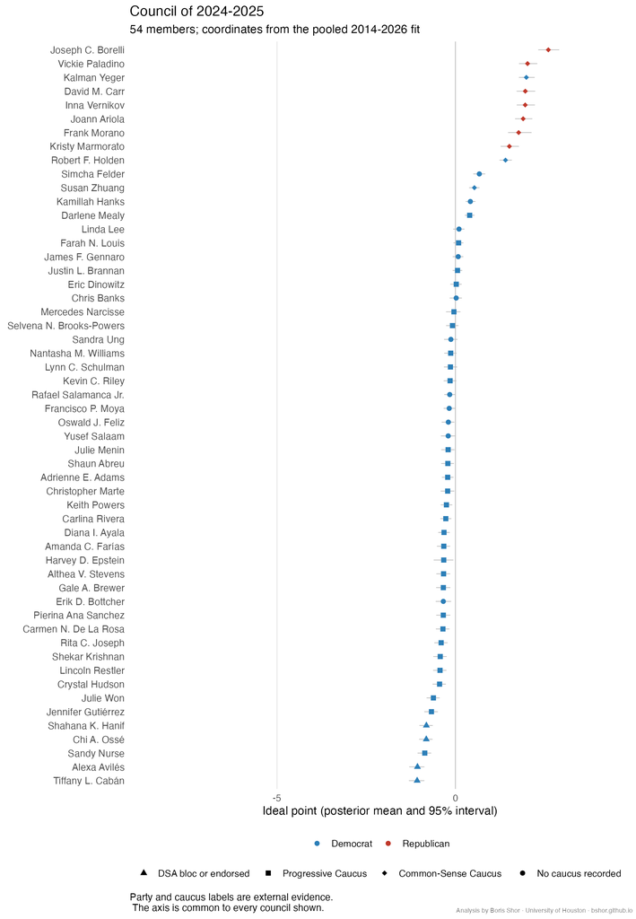

Members of the 2024–2025 council.

**2022–2023**

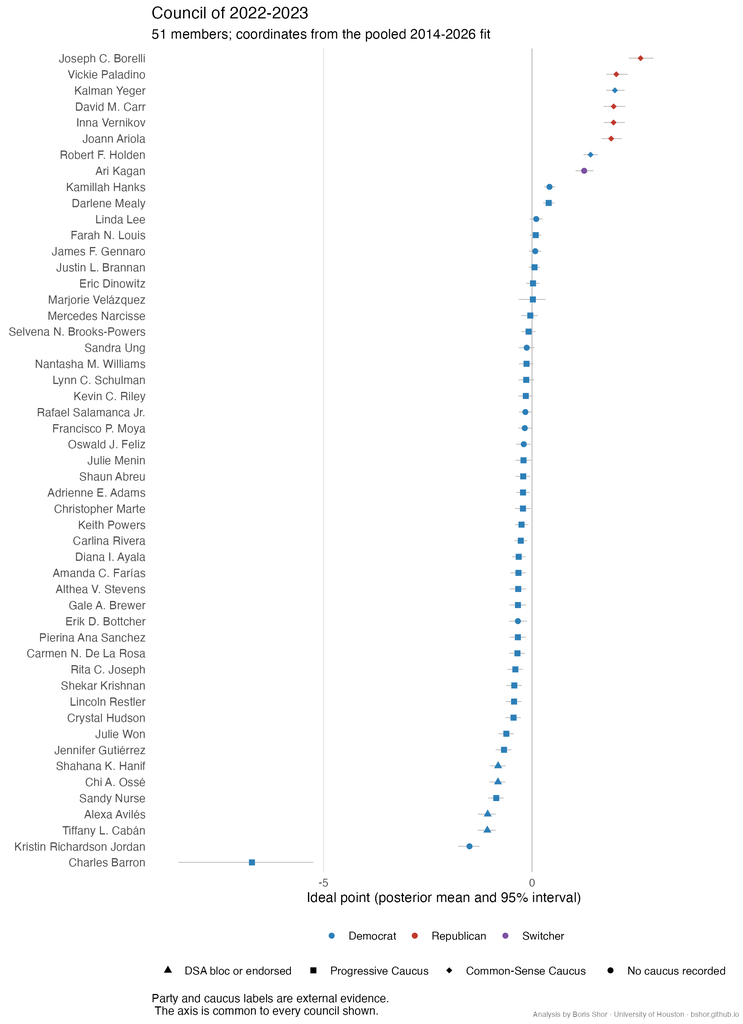

Members of the 2022–2023 council, the first elected after the 2021 turnover.

**2018–2021**

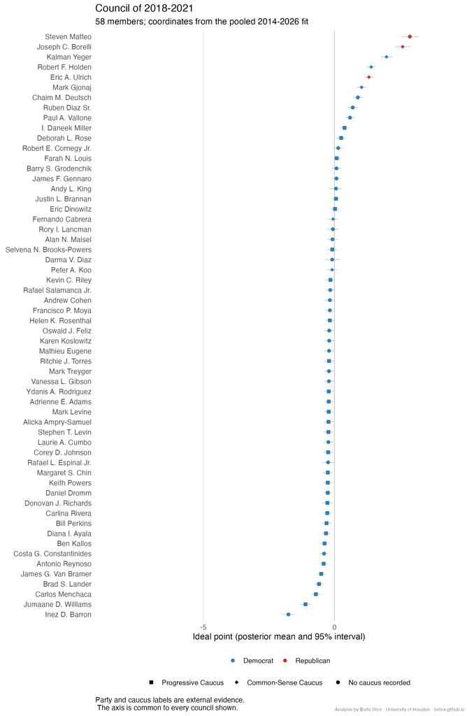

Members of the 2018–2021 council.

**2014–2017**

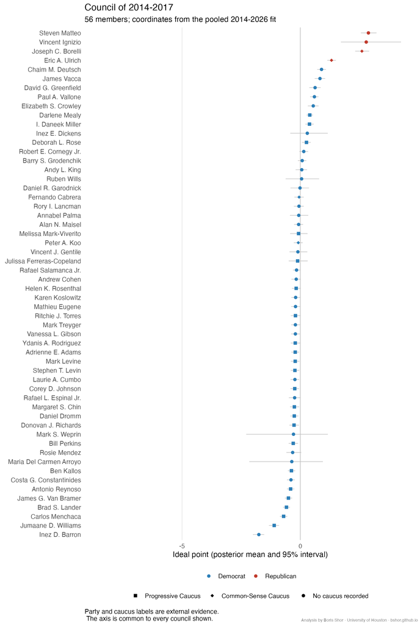

Members of the 2014–2017 council, the earliest in the record.

| Council | Members | Contested items voted |
| --- | --- | --- |
| 2014-2017 | 56 | 1,170 |
| 2018-2021 | 58 | 2,129 |
| 2022-2023 | 51 | 1,100 |
| 2024-2025 | 54 | 1,093 |
| 2026– | 52 | 350 |

The 2018–2021 council contributes by far the most contested votes; the council seated in 2026 has only eight months of record so far, which is why its intervals are wider than its size alone would suggest.

### Party and organizational groupings

Party affiliation is researched for all 123 fitted members. The ledger has 124 dated, source-cited records because Ari Kagan changed from Democrat to Republican during his service. Of the other members, 112 have Democratic evidence and 10 Republican evidence. The sources include the Council’s official roster, partisan primary returns, and candidate-supplied enrollment statements. They establish affiliation at documented dates, not uninterrupted enrollment across every year. General-election fusion lines are retained as a **separate electoral measure**, not used to assign party affiliation. Party labels are not predictors or prior constraints in the model; organizational memberships and endorsements are external comparisons.

| Group | Scope | In group | Outside | Median: group | Median: others | Median difference |
| --- | --- | --- | --- | --- | --- | --- |
| Researched affiliation: Republican | all 122 fixed-affiliation | 10 | 112 | 1.96 | -0.20 | 2.16 |
| Researched affiliation: Republican | current council | 5 | 47 | 1.96 | -0.21 | 2.17 |
| Common-Sense Caucus (ever) | all 123 | 16 | 107 | 1.46 | -0.21 | 1.67 |
| Progressive Caucus (ever) | all 123 | 61 | 62 | -0.27 | 0.04 | -0.30 |
| DSA campaign endorsement (ever) | all 123 | 2 | 121 | -1.07 | -0.17 | -0.89 |
| DSA officeholder bloc (ever) | all 123 | 4 | 119 | -0.94 | -0.16 | -0.78 |
| Also served in the state legislature | all 123 | 16 | 107 | -0.19 | -0.17 | -0.02 |

The five Republicans in the current council are its five most positive members. Across all twelve years, the party groups overlap slightly. The exceptions are instructive: Republican Eric Ulrich is slightly left of Democratic-affiliated Robert Holden and Kalman Yeger. Holden and Yeger appeared Republican under the old ballot-line display because they also ran on Republican fusion lines; their [Democratic primary](https://www.vote.nyc/sites/default/files/pdf/election_results/2021/20210622Primary%20Election/rcv/024414_1.html) and [candidate-stated enrollment](https://a860-gpp.nyc.gov/downloads/ms35tb08m?locale=en), respectively, resolve affiliation. Kagan’s [documented 2022 switch](https://council.nyc.gov/press/2022/12/05/2313/) is shown separately and his pooled position is excluded from the static party comparison. The Common-Sense Caucus sits toward the Republican end despite including Democrats; the Progressive Caucus and DSA measures sit toward the other end. State-legislative service shows little separation, as a biographical bridge rather than an ideological group should.

#### Dated caucus check

The pooled “ever” indicators above span twelve years. A narrower check compares members serving together in 2026 against the [Progressive Caucus’s September roster](https://council.nyc.gov/caucuses/progressive-caucus/) and the [Common-Sense Caucus roster](https://council.nyc.gov/caucuses/common-sense-caucus/), whose official membership records carry June 11 start dates and were observed in September. In each row, “unlisted” means not on that caucus’s complete roster at the specified date, not never a member. Negative values are toward the progressive end of the voting scale.

| Caucus | Scope | Listed | Unlisted | Median: listed | Median: unlisted | Median difference |
| --- | --- | --- | --- | --- | --- | --- |
| Progressive · Sep 2026 | All fixed-party members | 23 | 28 | -0.43 | 0.02 | -0.45 |
| Progressive · Sep 2026 | Democrats | 23 | 23 | -0.43 | -0.06 | -0.37 |
| Common-Sense · Jun 2026 | All fixed-party members | 6 | 45 | 1.29 | -0.21 | 1.50 |
| Common-Sense · Jun 2026 | Democrats | 3 | 43 | 0.53 | -0.22 | 0.75 |

Both distinctions remain visible *within Democrats*: the Progressive Caucus is to the left of other Democrats, while the Common-Sense Caucus is to their right. These are descriptive comparisons of pooled ideal points, not claims that caucus membership was constant through each member’s service. The [DSA campaign announcements](https://socialists.nyc/press-releases/nyc-dsa-re-endorses-council-members-alexa-aviles-tiffany-caban/) document positive endorsements, but do not establish a complete slate from which to code everyone else as unendorsed.

### District electorates

#### Every presidential election, 2016 to 2024

**2024**

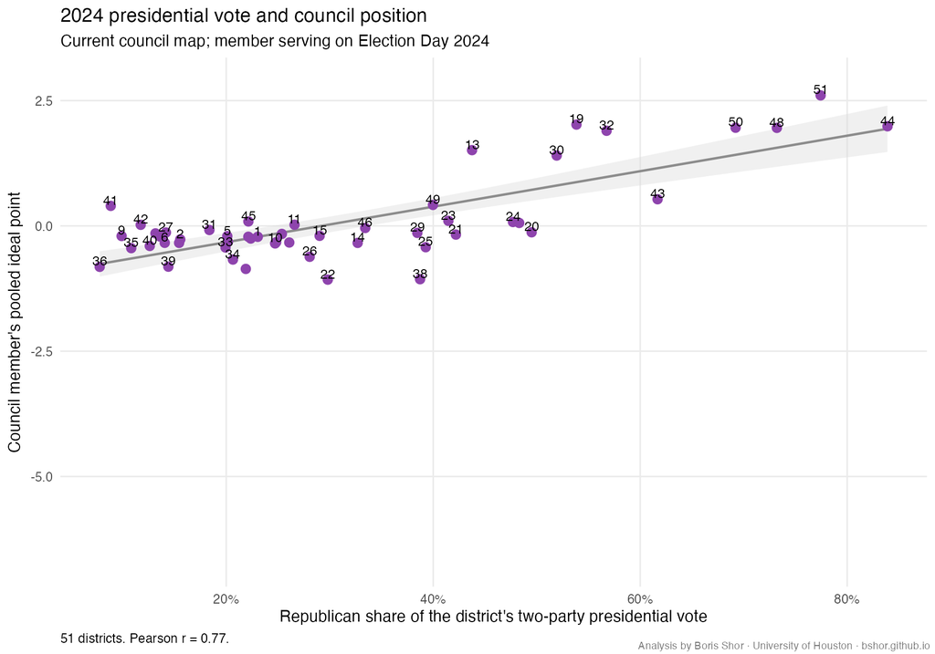

**2020**

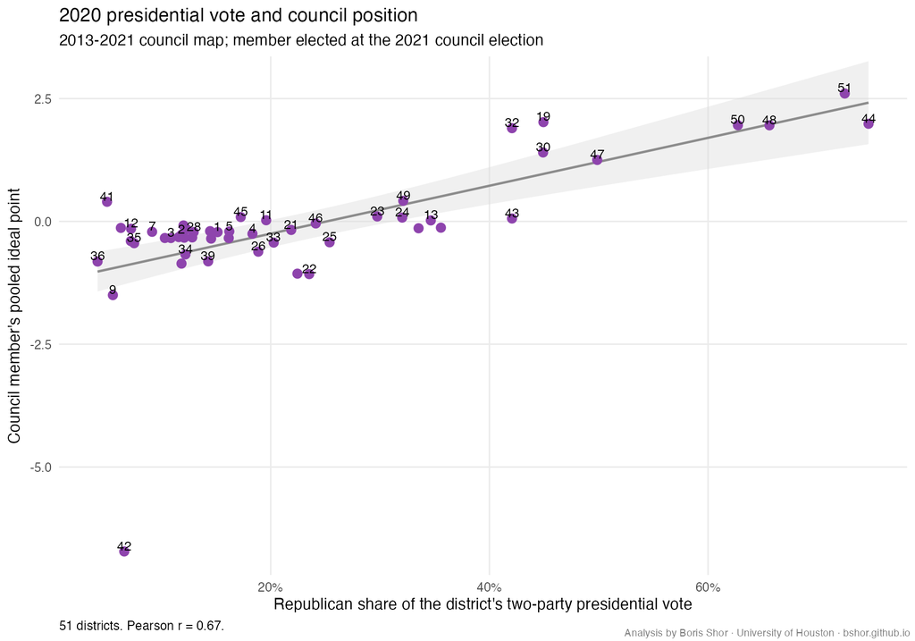

**2016**

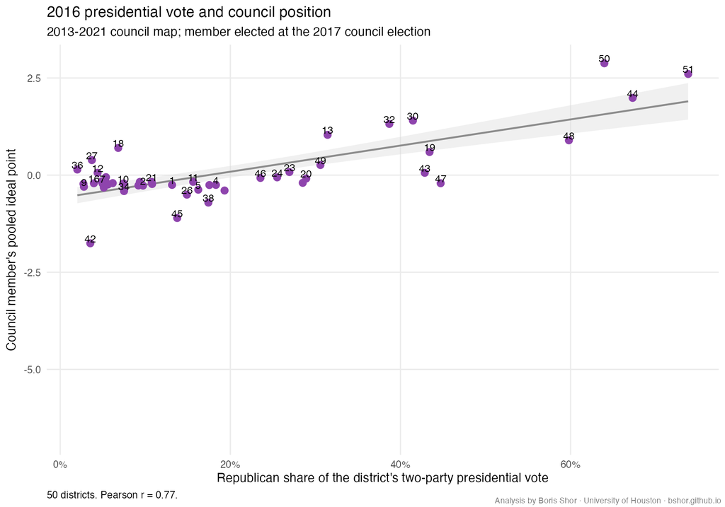

| Election | Districts | Pearson | Ideal points per 10 points | R² |
| --- | --- | --- | --- | --- |
| 2016 | 50 | 0.77 | 0.34 | 0.59 |
| 2020 | 51 | 0.67 | 0.49 | 0.45 |
| 2024 | 51 | 0.77 | 0.35 | 0.60 |

Two caveats attach to the earlier cycles. They sit on the **2013–2021 council map**, because New York redistricted after the 2020 census, so the district identities are not the current ones; and since the ballot record begins with the 2017 council election, each is matched to the member the district elected at the next council election on that same map — 2016 to the 2017 winners, 2020 to the 2021 winners. The 2024 cycle uses the current map and the member serving on Election Day. The 2016 comparison covers 50 districts because one 2017 winner never cast a retained vote.

#### Every mayoral election, 2017 to 2025 — the runner-up’s share

Mayoral ballots give a third independent comparison. The measure that carries across all three is the **runner-up’s** share of each district’s mayoral vote, set against the position of the council member elected on that same ballot. In 2017 and 2021 the runner-up was the Republican nominee — Malliotakis, then Sliwa — but in 2025 it was Andrew Cuomo on an independent line, with Sliwa a distant third on about 7 percent citywide. Using the Republican in 2025 would track a minor candidate rather than the actual opposition to the winner. Unlike council races, every district records a vote for each citywide candidate, so nothing is omitted here.

**2025**

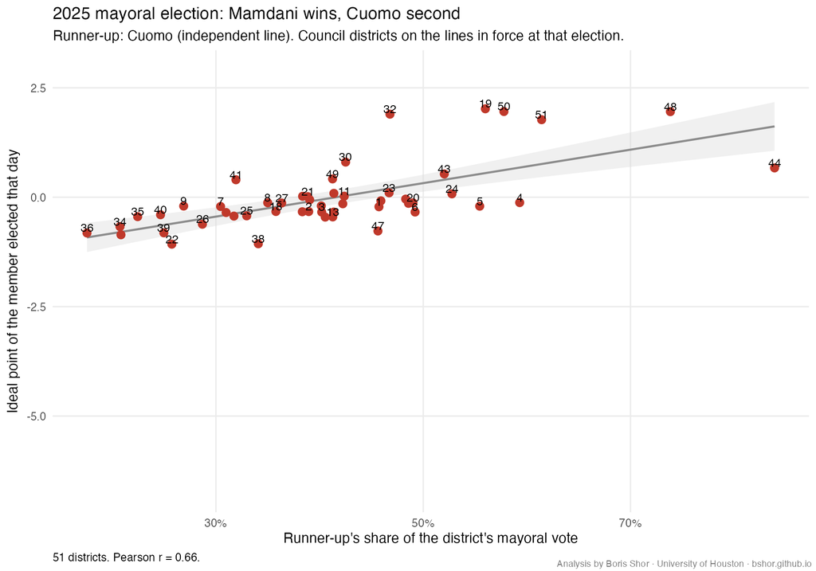

**2021**

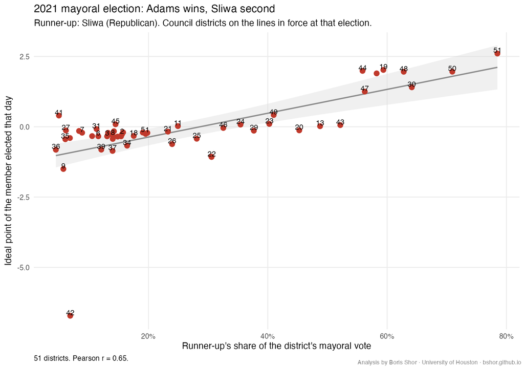

**2017**

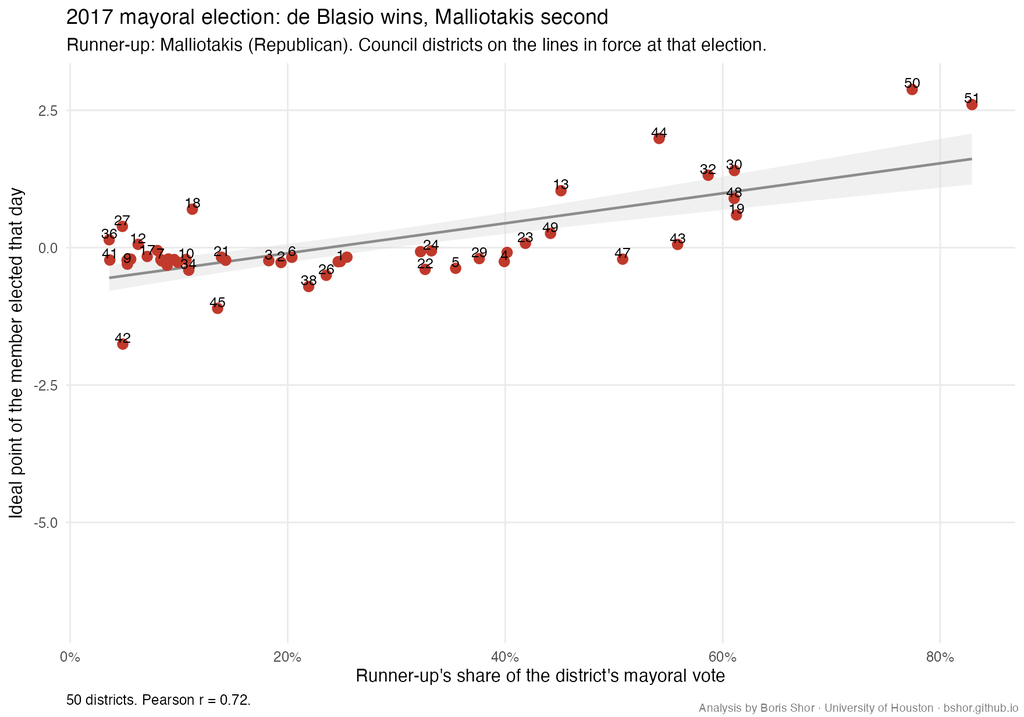

| Election | Districts | Runner-up | Pearson |
| --- | --- | --- | --- |
| 2017 | 50 | Malliotakis (Republican) | 0.72 |
| 2021 | 51 | Sliwa (Republican) | 0.65 |
| 2025 | 51 | Cuomo (independent line) | 0.66 |

##### The winner’s share

The same ballots read from the winning side give the mirror image: the mayor’s own share of a district’s vote, against the position of the council member elected there. The sign flips because a stronger showing for the winning Democrat marks a more progressive district.

**2025 · Mamdani**

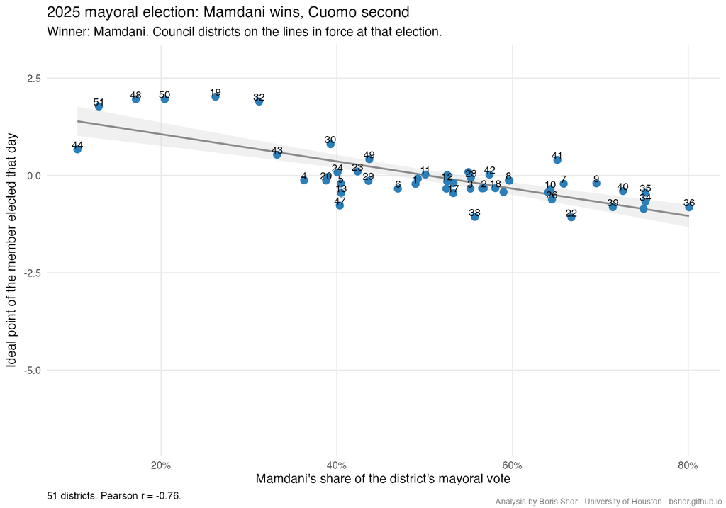

**2021 · Adams**

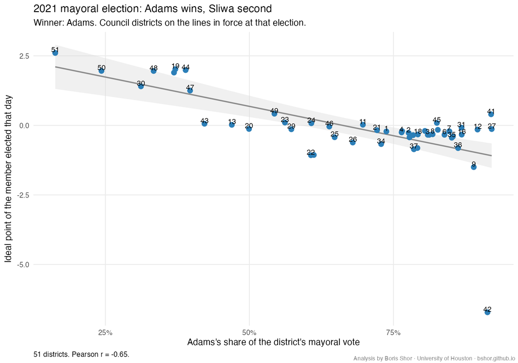

**2017 · de Blasio**

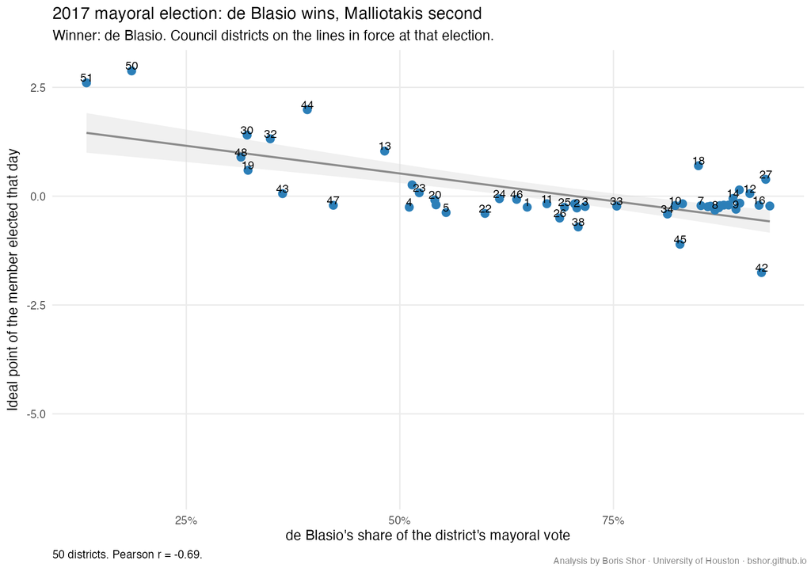

| Election | Winner | Pearson |
| --- | --- | --- |
| 2017 | de Blasio | -0.69 |
| 2021 | Adams | -0.65 |
| 2025 | Mamdani | -0.76 |

#### Every council election, 2017 to 2025

The same comparison repeats for each election that seated one of these councils: the Republican-line share of a district’s council vote against the position of the member it elected. Only districts **where a Republican-line candidate actually ran** are shown. A district with no Republican on the ballot records a structural zero — the party did not contest the seat — which is not the same quantity as a district where Republicans ran and lost, and including those zeros understates the relationship. Between 13 and 21 of the 51 districts go uncontested in each cycle. Among contested districts the association is strong in every year (Pearson 0.81 to 0.87).

**2025**

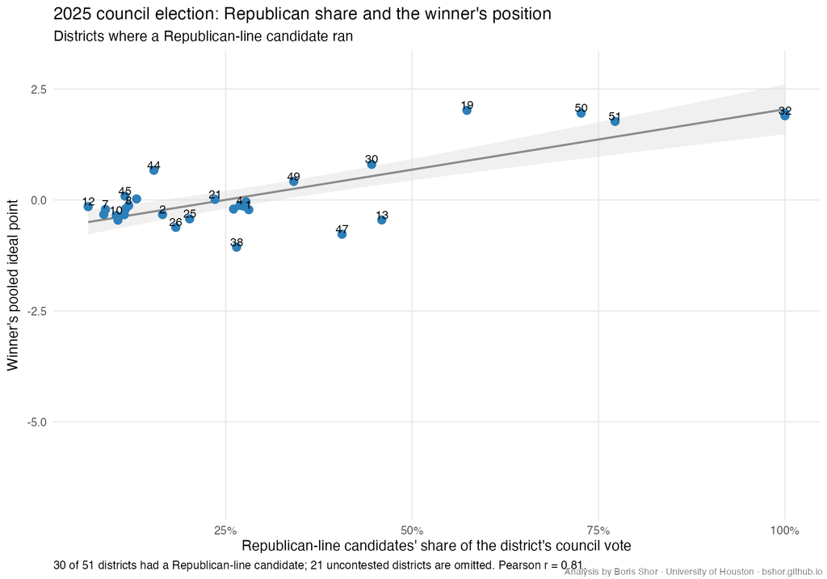

**2023**

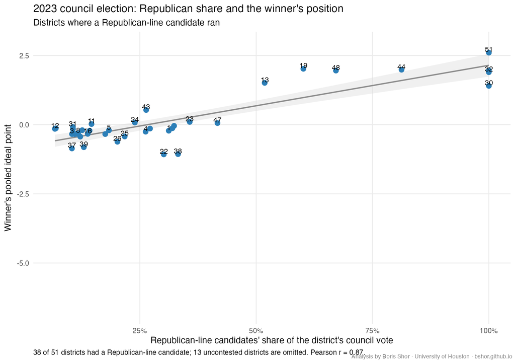

**2021**

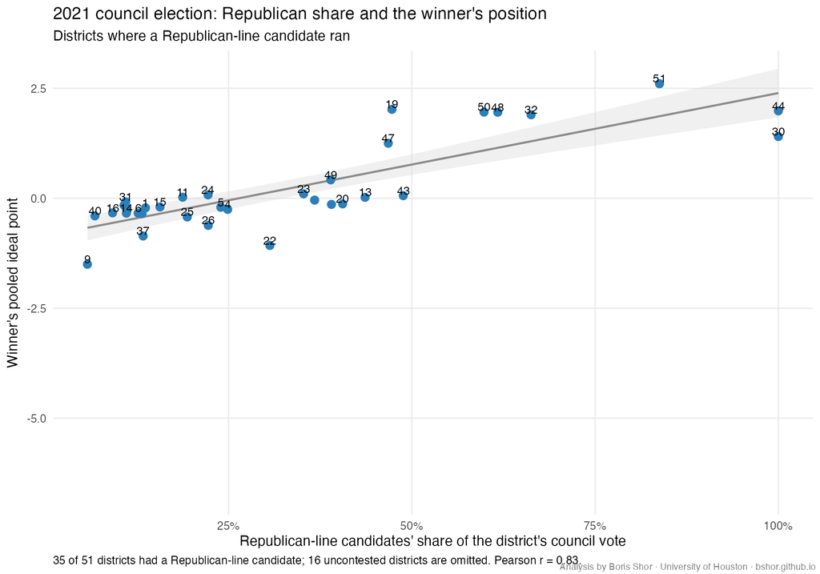

**2017**

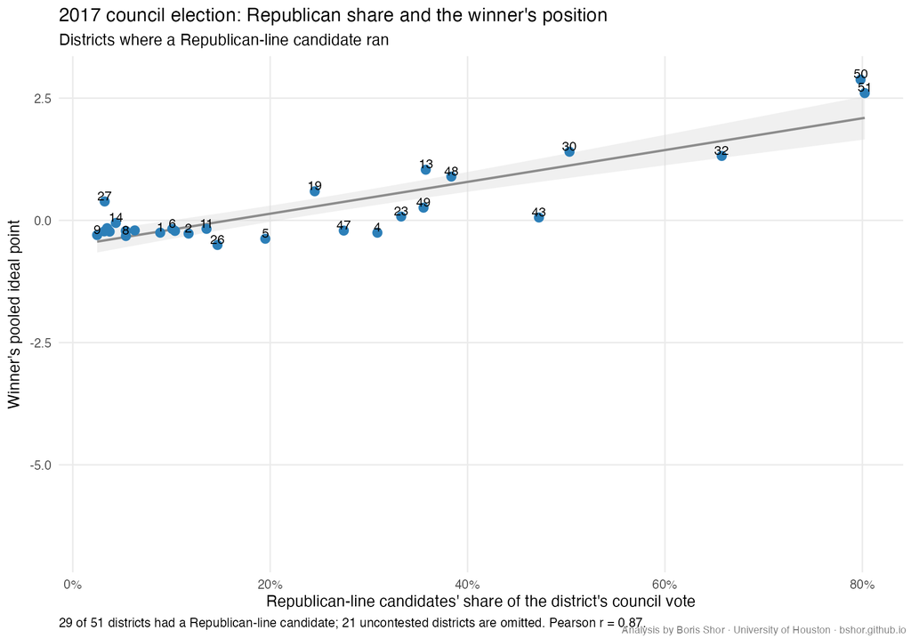

| Election | Contested districts | Uncontested, omitted | Pearson |
| --- | --- | --- | --- |
| 2017 | 29 | 21 | 0.87 |
| 2021 | 35 | 16 | 0.83 |
| 2023 | 38 | 13 | 0.87 |
| 2025 | 30 | 21 | 0.81 |

One 2017 winner never cast a retained vote and so has no coordinate, which is why that year starts from 50 districts rather than 51.

In 2024 Trump’s two-party share correlates 0.77 with council position across all 51 districts. A ten-point increase corresponds to 0.35 ideal-point units. The council’s own elections give a similar independent check. The mayoral comparison runs the other way: districts where Mamdani polled better elected more progressive members (-0.76).

The mayoral figures come from the Board of Elections election-district files, aggregated to all 51 council districts using the same election’s council result files as the crosswalk — all 4,117 in-play election districts match exactly one district. The presidential figures aggregate the *New York Times* published precinct polygons to the council boundaries. [BOE 2025 results](https://vote.nyc/page/election-results-summary-2025); [*New York Times* precinct data](https://github.com/nytimes/presidential-precinct-map-2024)

## Placing the council on the state scale

Sixteen people in this analysis also served in the New York State Assembly or Senate, where the Shor–McCarty common space already measures legislators on a national scale. Those overlapping careers make it possible to express the council’s coordinates in those units — the same bridging logic used in the state-legislature project, applied here to a city council.

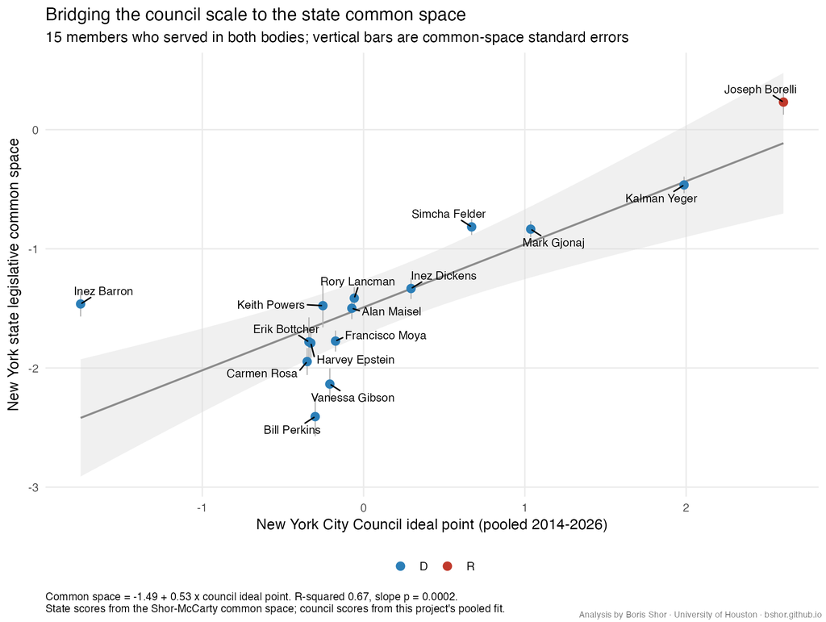

The 15 members used in calibration, excluding Charles Barron. Horizontal position is the council ideal point; vertical position is the state common space, with its standard errors.

Charles Barron is excluded from calibration because his council position is unusually extreme and uncertain; Inez Barron remains included. Across the remaining **15 bridges**, the scales have a clear positive association (Pearson 0.82, R² 0.67). The following state-space displays show the fitted linear mapping; its uncertainty is not included in the displayed member positions.

| Term | Estimate | Std. error | t | p |
| --- | --- | --- | --- | --- |
| Intercept | -1.491 | 0.107 | -13.88 | 3.6e-09 |
| Slope (council ideal point) | 0.529 | 0.104 | 5.08 | 0.00021 |

Applying those coefficients to all 123 members puts the council in state units. This is a linear transform, so it changes no member’s rank — what it fixes is where the council sits, and how wide it is, relative to legislators in Albany.

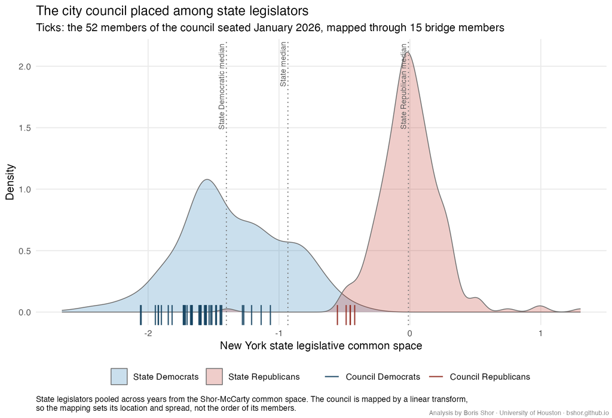

The council seated in January 2026 against the distribution of New York state legislators.

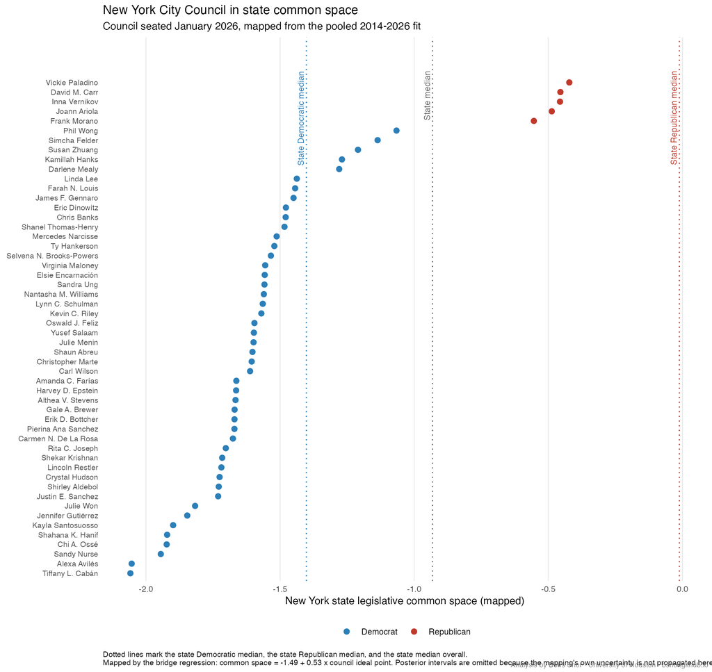

Each current council member’s mapped position in state common space.

### The same city, two legislatures

The state comparison can be tightened. Rather than setting the council against every legislator in Albany, it can be set against the state legislators who represent **the same constituents** — those whose districts lie inside the five boroughs. Census boundaries put 65 of 150 assembly districts and 28 of 63 senate districts majority-inside the city.

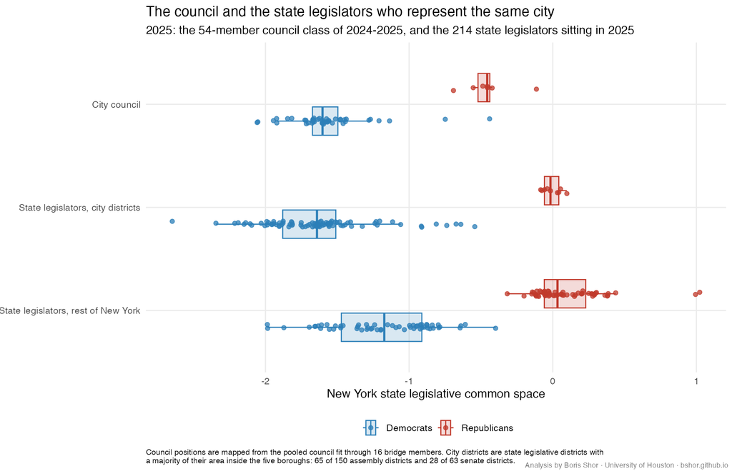

The 2024–2025 council class and the state legislators sitting in 2025, split by party and by whether the state district lies inside the city.

| Group | Dem. n | Dem. median | Rep. n | Rep. median | Party gap |
| --- | --- | --- | --- | --- | --- |
| City council (2024-2025) | 47 | -1.60 | 7 | -0.46 | 1.15 |
| State legislators representing city districts | 88 | -1.64 | 9 | -0.02 | 1.63 |
| State legislators elsewhere in New York | 58 | -1.17 | 59 | 0.03 | 1.21 |
| All state legislators | 146 | -1.55 | 68 | 0.03 | 1.57 |

The city’s two legislatures line up closely on the Democratic side: the council’s Democrats sit at -1.60 against -1.64 for state legislators from city districts — a difference far smaller than the one separating those state legislators from Democrats elsewhere in New York (-1.17).

The Republican side differs much more. The council’s 7 Republican-affiliated members have a median of -0.46, while the 9 state Republicans from city districts sit at -0.02 — near the median for Republicans elsewhere in the state (0.03). The city council’s Republicans are markedly less conservative on the mapped scale than the Albany Republicans representing the same city.

That asymmetry is the most interesting thing the bridge produces. It suggests the council’s partisan divide is compressed relative to the state’s: its Democrats are typical city Democrats, but its Republicans are not typical city Republicans. Whether that reflects the council’s own agenda, the kind of Republican who runs for city office, or the mapping’s compression of a small group is not something these data settle.

### Each council against its own legislature

Each council can be read against the legislators sitting in Albany during its own years. The two state rows collapse hundreds of legislators into one row per party: a diamond at the party median, a thick bar across the interquartile range, and a thin bar across the 10th to 90th percentile.

**2026–**

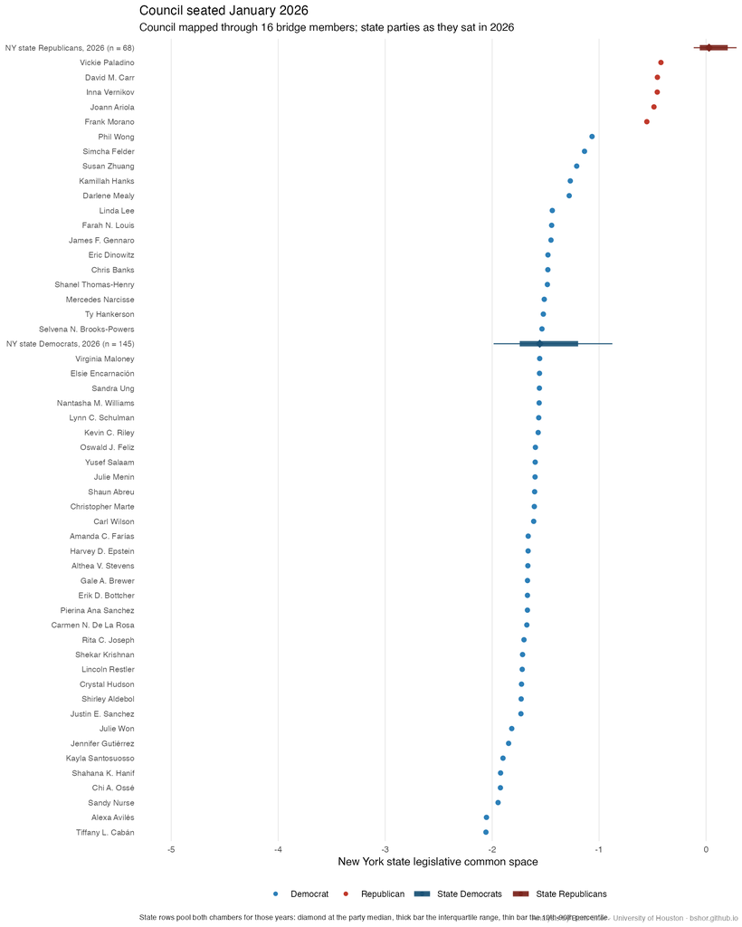

**2024–2025**

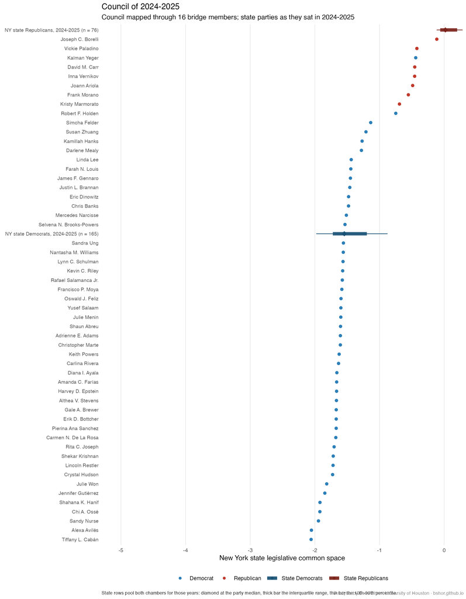

**2022–2023**

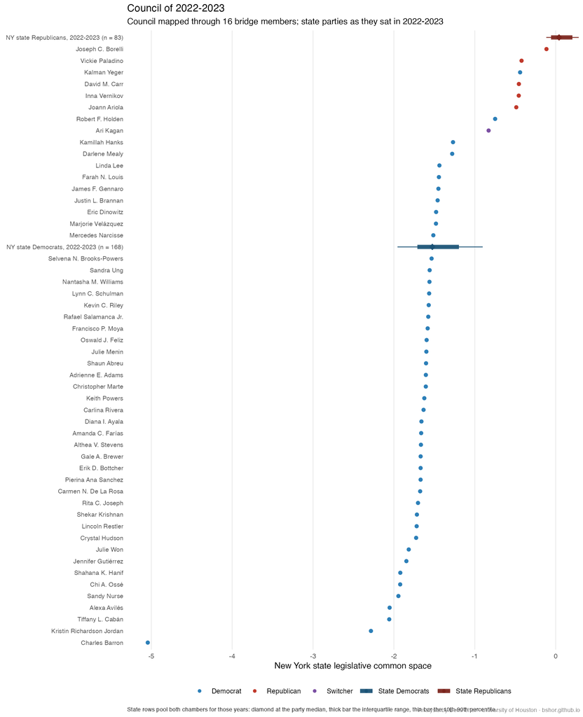

**2018–2021**

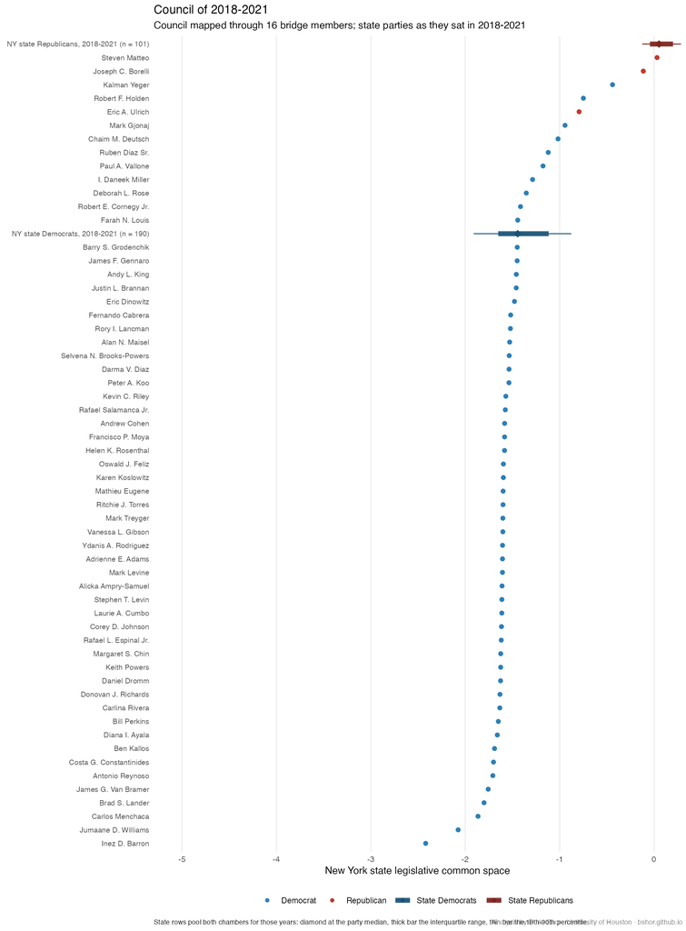

**2014–2017**

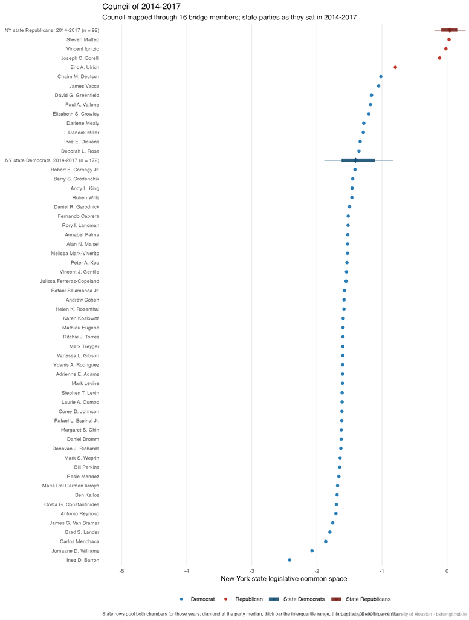

| Council | Council Dems | Council Dem. median | State Dem. median | Gap | Council Reps | Council Rep. median | State Rep. median | Gap |
| --- | --- | --- | --- | --- | --- | --- | --- | --- |
| 2014-2017 | 52 | -1.60 | -1.41 | -0.19 | 4 | -0.07 | 0.04 | -0.11 |
| 2018-2021 | 55 | -1.60 | -1.44 | -0.15 | 3 | -0.11 | 0.05 | -0.17 |
| 2022-2023 | 45 | -1.61 | -1.52 | -0.08 | 5 | -0.45 | 0.04 | -0.50 |
| 2024-2025 | 47 | -1.60 | -1.54 | -0.06 | 7 | -0.46 | 0.02 | -0.48 |
| 2026– | 47 | -1.60 | -1.55 | -0.05 | 5 | -0.46 | 0.03 | -0.48 |

Comparing each party with its own counterpart in Albany separates two very different findings.

**Under this mapping, the council’s Democrats remain near the state Democratic medians.** The gap moves from -0.19 in 2014–2017 to -0.05 in the current council. The mapped council median changes little, while the state Democratic benchmark moves left, from -1.41 to -1.55.

**The mapping places council Republicans left of state Republicans.** Their median sits 0.48 units to the left of the state Republican median in the current council, and between 0.11 and 0.50 units left across the series. This comparison depends on the estimated transform and should not by itself be read as proof that city and state Republicans differ ideologically.

Two cautions. The Republican medians rest on few members — 4 in 2014–2017, 5 now — so they move easily. The affiliation ledger covers every fitted member, including the earliest class, but the source dates do not prove continuous enrollment throughout service. Kagan’s one pooled coordinate crosses a documented party switch and enters neither party median for the 2022–2023 class.

The mapping multiplies distances on the council scale by the estimated slope, 0.53, when expressing them in state units. This changes the numerical spread, not members’ ordering.

The bridge uses fifteen people, excluding Charles Barron’s uncertain position. The state scores pool legislators across many years rather than describing one sitting legislature, and the mapping’s own uncertainty is not propagated into the member positions shown here. These are point estimates of a transform, not posterior intervals.

## Interpretation and limits

The voting scale distinguishes party groups, organized caucuses and district electorates. The state bridge offers a common-space comparison, but its mapping uncertainty is not shown in the member plots. Estimation and construction limits are detailed in the technical appendix.